# Laboratorio R per le scienze sociali – Giorno 5

Federico Vegetti

Let us load the data:

```r
library(rio)
setwd("/folder/where/you/keep/the/data")
cses <- import("cses2018small.xlsx")
```

# Data management con `dplyr`

`dplyr` è una libreria che ci semplifica di molto le cose quando si tratta di lavorare con database in R. `dplyr` è parte di una collezione di librerie chiamata `tidyverse`, che abbiamo già menzionato qualche giorno fa. Si può installare nel solito modo:

```r
install.packages("tidyverse", dependencies = T)
```

Naturalmente è possibile installare anche solo `dplyr` individualmente, senza le altre librerie del `tidyverse`, tuttavia useremo anche altre librerie presenti nel `tidyverse`, e inoltre alcune funzionalità che si utilizzano in `dplyr` provengono in ogni caso da altre librerie della collezione. Da un certo punto di vista possiamo considerare `tidyverse` come un “ecosistema” di funzioni, che da il meglio di sé quando viene utilizzato in modo integrato.

**Nota1**: per interagire al meglio da `dplyr` e con altre funzioni del `tidyverse` dobbiamo utilizzare un linguaggio leggermente diverso rispetto a quello che utilizziamo con R base. Metaforicamente, pensate a un gergo tecnico che in un ambito ben specifico aiuta a esprimersi in modo molto più efficiente. Non è completamente diverso dal linguaggio di R base, ma ci sono alcune differenze importanti che vedremo.

**Nota 2**: tutto quello che vedremo fatto con `dplyr` oggi può naturalmente essere fatto anche con R base (molte di queste cose le abbiamo viste nella scorsa sessione). Ovviamente questo vale per ogni funzione da ogni libreria di R. Il modo in cui le librerie come `dplyr` ci aiutano è rendendo il processo più veloce e, in molti casi, facendoci scrivere meno codice.

PEr incominciare carichiamo il `tidyverse`:

```r
library(tidyverse)
```

Ora guarderemo alcune delle funzioni più comuni di `dplyr`.

## Selezionare variabili con `select()`

La funzione `select()` serve per selezionare una o più **colonne** in un dataset, esattamente come le parentesi quadre `[`. Per esempio, possiamo selezionare solo le variabili `mip1` e `mip2` dal nostro dataset `cses`.

```r
cses_pg <- select(cses, mip1, mip2)
head(cses_pg)
```

```
##             mip1           mip2
## 1      la scuola      il lavoro
## 2           <NA>           <NA>
## 3 poverta,lavoro   immigrazione
## 4      il lavoro   immigrazione
## 5         lavoro   immigrazione
## 6      il lavoro l'immigrazione
```

Per renderci la vita più facile, con `dplyr` abbiamo a disposizione delle funzioni che ci permettono di selezionare gruppi di variabili senza dover scrivere tutti i nomi uno per uno.

- `starts_with()`: seleziona le variabili basate su un **prefisso** comune

```r
cses_pg <- select(cses, starts_with("mip"))
```

- `ends_with()`: seleziona le variabili basate su un **suffisso** comune

```r
cses_pg <- select(cses, ends_with("1"), ends_with("2"))
```

- `contains()`: più in generale, seleziona le variabili sulla base di una sequenza di caratteri presenti all’interno dei loro nomi

```r
cses_pg <- select(cses, contains("ea"))

cses_pg <- select(cses, contains("e"), contains("a"))
```

Naturalmente possono essere combinati

```r
cses_pg <- select(cses, starts_with("eta"), ends_with("gr"))
```

**Nota**: gli oggetti prodotti da `dplyr` sembrano data frame, ma in realtà appartengono a un formato leggermente diverso chiamato “*tibble*”. Questo si nota perchè se chiedete a R di mostrarvi il dataset, l’output includerà la frase `A tibble: n x n` (il numero di righe e colonne) e altre informazioni sul tipo di valore (`<dbl>`, `<chr>`) sotto ai nomi delle variabili.

Il formato *tibble* è quasi identico al data frame, l’unica differenza è che è ottimizzato per essere usato con le funzioni che sono parte del `tidyverse`. Per la maggior parte degli usi che se ne possono fare, non c’è alcuna differenza tra i formati tibble e data frame. Inoltre, in caso di necessità, è sempre possibile convertire un tibble in data frame con la funzione `as.data.frame()`.

```r
cses_pg <- as.data.frame(cses_pg)
```

## Selezionare osservazioni con `filter()` e `slice()`

La funzione `filter()` serve per selezionare una o più **righe** in un dataset, e anche in questo caso fa quello che faremmo in R base usando le parentesi quadre `[`. Per esempio, possiamo selezionare solo gli intervistati che vivono nelle regioni del nord Italia, hanno più di 35 anni e pensano che durante l’anno prima delle elezioni la situazione economica del paese sia peggiorata.

```r
cses_pg <- filter(
  cses,
  area %in% c("Nord-Ovest", "Nord-Est"),
  eta > 35,
  eco_eval == -1
)
head(cses_pg)
```

```
##   id     sex eta eta_gr           mip1            mip2 eco_eval       area
## 1  3 Femmina  68    55+ poverta,lavoro    immigrazione       -1   Nord-Est
## 2  5 Femmina  54  35 54         lavoro    immigrazione       -1 Nord-Ovest
## 3 20 Femmina  65    55+         lavoro crisi economica       -1 Nord-Ovest
## 4 27 Femmina  57    55+     burocrazia        politica       -1   Nord-Est
## 5 35 Femmina  45  35 54 disoccupazione    immigrazione       -1 Nord-Ovest
## 6 88 Maschio  51  35 54      sicurezza    immigrazione       -1   Nord-Est
```

La funzione `slice()` (e tutte le sue versioni specifiche), invece è l’equivalente di utilizzare le parentesi quadre `[` con i numeri di indice:

```r
# Alcune osservazioni a caso nel dataset
slice(cses, c(1, 2, 10, 35, 3))
```

```
##   id     sex eta eta_gr              mip1         mip2 eco_eval       area
## 1  1 Femmina  60    55+         la scuola    il lavoro       -1        Sud
## 2  2 Maschio  62    55+              <NA>         <NA>       -1     Centro
## 3 10 Femmina  37  35 54 la disoccupazione   la poverta       -1        Sud
## 4 35 Femmina  45  35 54    disoccupazione immigrazione       -1 Nord-Ovest
## 5  3 Femmina  68    55+    poverta,lavoro immigrazione       -1   Nord-Est
```

- `slice_sample()` permette di estrarre alcune osservazioni casuali:

```r
# 5 osservazioni casuali
slice_sample(cses, n = 5)
```

```
##     id     sex eta eta_gr                     mip1         mip2 eco_eval   area
## 1  185 Maschio  52  35 54            l'occupazione la sicurezza       -1    Sud
## 2 1303 Maschio  62    55+                 legalita       lavoro        0    Sud
## 3  127 Maschio  29  18 34             Immigrazione   Corruzione        0    Sud
## 4  237 Maschio  64    55+                   Lavoro   Corruzione        0    Sud
## 5  101 Femmina  77    55+ disoccupazione giovanile         <NA>        1 Centro
```

- `slice_head()` e `slice_tail()` permettono di estrarre le *prime* o *ultime* `n` osservazioni:

```r
# Prime 5 osservazioni nel dataset
slice_head(cses, n = 5)
```

```
##   id     sex eta eta_gr           mip1         mip2 eco_eval       area
## 1  1 Femmina  60    55+      la scuola    il lavoro       -1        Sud
## 2  2 Maschio  62    55+           <NA>         <NA>       -1     Centro
## 3  3 Femmina  68    55+ poverta,lavoro immigrazione       -1   Nord-Est
## 4  4 Maschio  62    55+      il lavoro immigrazione       -1        Sud
## 5  5 Femmina  54  35 54         lavoro immigrazione       -1 Nord-Ovest
```

```r
# Ultime 5 osservazioni nel dataset
slice_tail(cses, n = 5)
```

```
##     id     sex eta eta_gr                                mip1                    mip2 eco_eval       area
## 1 1997 Femmina  67    55+                           il lavoro                   farlo        1 Nord-Ovest
## 2 1998 Maschio  48  35 54                   la disoccupazione la negatività nel paese        0        Sud
## 3 1999 Maschio  73    55+                              lavoro educazione dei citadini       -1        Sud
## 4 2000 Femmina  44  35 54 razzismo al livello degli attentati               il lavoro       -1     Centro
## 5 2001 Femmina  67    55+                              lavoro                pensioni       -1 Nord-Ovest
```

## Rinominare le variabili con `rename()`

Una funzione abbastanza pratica per cambiare i nomi alle variabili, come faremmo con Stata

```r
cses_pg <- rename(
  cses_pg,
  eta_groups = eta_gr
)
names(cses_pg)
```

```
## [1] "id"         "sex"        "eta"        "eta_groups" "mip1"       "mip2"       "eco_eval"   "area"
```

## Aggiungere variabili con `_join()`

`dplyr` offre una serie di funzioni per aggiungere variabili a un dataset (ovvero quello che viene chiamato comunemente *merge* o nel linguaggio di SQL, “*join*”) seguendo diversi criteri. Tutte queste funzioni hanno lo stesso suffisso e sono strutturate nello stesso modo: `_join(x, y, by = var)`, dove `x` è il dataset che stiamo utilizzando e che vogliamo usare come “base”, `y` è il dataset le cui variabili vogliamo aggiungere a `x`, e `var` è la variabile “ponte” che viene usata per assegnare i valori corretti alle osservazioni corrette.

La lista completa delle possibili soluzioni che `dplyr` offre per unire diversi dataset può essere trovata [qui](https://dplyr.tidyverse.org/reference/join.html). Le più comuni sono:

- `left_join()`: mantiene tutte le osservazioni in `x`. Se `y` ha meno osservazioni di `x`, le variabili in `y` saranno `NA` per le righe in `x` che non sono presenti in `y`. Se `y` ha più osservazioni di `x`, le righe in eccesso verranno eliminate. Il numero di osservazioni nel dataset risultante sarà lo stesso numero di osservazioni in `x`.
- `right_join()`: l’esatto contrario, ovvero mantiene tutte le osservazioni in `y`, ecc.
- `inner_join()`: mantiene tutte le osservazioni che sono **sia** in `x` **che** in `y` (intersezioni di insiemi).
- `full_join()`: mantiene le osservazioni che sono in `x` **oppure** in `y` (quindi tutte le osservazioni in entrambi i dataset, unione di insiemi).

Vediamo il solito esempio con il file `cses2018edu.dta`:

```r
cses <- left_join(
  cses,
  import("cses2018edu.dta"),
  by = "id"
)
head(cses)
```

```
##   id     sex eta eta_gr           mip1           mip2 eco_eval       area titstu
## 1  1 Femmina  60    55+      la scuola      il lavoro       -1        Sud      9
## 2  2 Maschio  62    55+           <NA>           <NA>       -1     Centro      5
## 3  3 Femmina  68    55+ poverta,lavoro   immigrazione       -1   Nord-Est      5
## 4  4 Maschio  62    55+      il lavoro   immigrazione       -1        Sud      6
## 5  5 Femmina  54  35 54         lavoro   immigrazione       -1 Nord-Ovest      5
## 6  6 Femmina  71    55+      il lavoro l'immigrazione        0 Nord-Ovest      4
```

## Creare e trasformare variabili con `mutate()`

Questa è una delle funzioni più utilizzate in `dplyr`. Può essere usata sia per operazioni di ricodifica molto semplici e anche cose più difficili. Per esempio, possiamo standardizzare la variabile `eta`, come abbiamo fatto l’ultima volta:

```r
cses_pg <- mutate(
  cses,
  eta_std = scale(eta)
)
head(cses_pg)
```

```
##   id     sex eta eta_gr           mip1           mip2 eco_eval       area titstu   eta_std
## 1  1 Femmina  60    55+      la scuola      il lavoro       -1        Sud      9 0.5124959
## 2  2 Maschio  62    55+           <NA>           <NA>       -1     Centro      5 0.6317059
## 3  3 Femmina  68    55+ poverta,lavoro   immigrazione       -1   Nord-Est      5 0.9893360
## 4  4 Maschio  62    55+      il lavoro   immigrazione       -1        Sud      6 0.6317059
## 5  5 Femmina  54  35 54         lavoro   immigrazione       -1 Nord-Ovest      5 0.1548658
## 6  6 Femmina  71    55+      il lavoro l'immigrazione        0 Nord-Ovest      4 1.1681511
```

Per le variabili categoriche, `dplyr` offre la comoda (seppur non sempre intuitiva) funzione `recode()`. Alcuni esempi:

```r
cses_pg <- mutate(
  cses,
  area2 = recode(area,              # Categoria singola per "Nord"
                 "Nord-Ovest" = "Nord",
                 "Nord-Est" = "Nord",
                 "Centro" = "Centro",
                 "Sud" = "Sud"),
  area3 = recode(area,              # Le osservazioni del "Nord-Ovest" diventano missing
                 "Nord-Ovest" = NA_character_,
                 "Nord-Est" = "Nord",
                 "Centro" = "Centro",
                 "Sud" = "Sud"),
  eco_neg = recode(eco_eval,        # Variabile dummy per valutazione negativa dell'economia
                   `-1` = 1,
                   .default = 0)
)
# Controllare le ricodifiche
table(cses_pg$area, cses_pg$area2)
```

```
##
##              Centro Nord Sud
##   Centro        446    0   0
##   Nord-Est        0  349   0
##   Nord-Ovest      0  553   0
##   Sud             0    0 653
```

```r
table(cses_pg$area, cses_pg$area3)
```

```
##
##              Centro Nord Sud
##   Centro        446    0   0
##   Nord-Est        0  349   0
##   Nord-Ovest      0    0   0
##   Sud             0    0 653
```

```r
table(cses_pg$eco_eval, cses_pg$eco_neg)
```

```
##
##        0   1
##   -1   0 646
##   0  823   0
##   1  509   0
```

Naturalmente si può sempre utilizzare la cara vecchia funzione `ifelse()`:

```r
cses_pg <- mutate(
  cses,
  eta_gr2 = ifelse(cses$eta <= 30, "<=30",
                   ifelse(cses$eta <= 50, "31-50",
                          "51+"))
)
```

## Mettere tutto assieme: l’operatore “pipe” `%>%`

L’operatore *pipe* è quello che rende `dplyr` speciale. È una funzione che serve a **concatenare** altre funzioni. Tuttavia questo cambia completamente la logica del linguaggio di R.

Per darvi un’idea della logica, Andrew Heiss fa un ottimo esempio in [questo tweet](https://twitter.com/andrewheiss/status/1173743447171354624). Immaginate che dovete scrivere un programma con le istruzioni per svegliarsi la mattina e uscire di casa per andare al lavoro. In R, utilizzando gli oggetti, questo verrebbe scritto nel seguente modo (in Inglese, perchè in Italiano viene male):

```r
me
me_awake <- wake_up(me)
me_out_of_bed <- get_out_of_bed(me_awake)
me_dressed <- get_dressed(me_out_of_bed)
me_out <- leave_house(me_dressed)
```

Quindi, prima usiamo la funzione `wake_up()` con l’oggetto `me`, poi usiamo la funzione `get_out_of_bed()` con l’oggetto `me_awake`, risultante dall’operazione precedente, e così via.

Tutta questa sequenza può anche essere scritta inserendo le funzioni una dentro l’altra:

```r
me_out <- leave_house(get_dressed(get_out_of_bed(wake_up(me))))
```

In tal caso iniziamo a scrivere partendo dall’ultima funzione, e man mano che scriviamo procediamo al contrario, *da fuori a dentro*, fino ad arrivare all’oggetto di partenza.

Ora, l’operatore *pipe* ci permette di concatenare tutte queste funzioni in modo che (1) non dobbiamo creare troppi oggetti–come faremmo se volessimo programmare in sequenza, e (2) non dobbiamo scrivere la sequenza dalla fine verso l’inizio–come faremmo se volessimo mettere le funzioni una dentro l’altra. Utilizzando il *pipe*, la nostra sequenza sarebbe:

```r
me_out <- me %>%
  wake_up() %>%
  get_out_of_bed() %>%
  get_dressed() %>%
  leave_house()
```

In altre parole, l’operatore *pipe* permette di svolgere le nostre operazioni di data management in modo sequenziale. Per esempio, possiamo fare tutte le operazioni che abbiamo visto partendo dal dataset originale e creando un oggetto alla fine:

```r
cses_pg <- cses %>%                     # Partiamo dal dataset "cses"
  select(eta, area) %>%                 # Selezionare variabili
  filter(eta > 40) %>%                  # Selezionare osservazioni
  mutate(
    area2 = recode(area,                # Creare una nuova variabile
                 "Nord-Ovest" = "Nord",
                 "Nord-Est" = "Nord",
                 "Centro" = "Centro",
                 "Sud" = "Sud")
    )
head(cses_pg)
```

```
##   eta       area  area2
## 1  60        Sud    Sud
## 2  62     Centro Centro
## 3  68   Nord-Est   Nord
## 4  62        Sud    Sud
## 5  54 Nord-Ovest   Nord
## 6  71 Nord-Ovest   Nord
```

## Fare operazioni per gruppi con `group_by()`

Ora che sappiamo come funziona l’operatore *pipe*, possiamo tirare fuori il meglio da `dplyr`. Una delle caratteristiche più utili di `dplyr` (e probabilmente la ragione per cui molte persone iniziano ad usarlo) è la possibilità di *eseguire operazioni per diversi gruppi* all’interno dei dati. Questo può sembrare banale (SPSS e Stata lo rendono piuttosto facile da fare), tuttavia farlo con R base non è affatto intuitivo.

Per esempio, possiamo centrare la variabile `eta` intorno alla media come abbiamo fatto prima, ma invece di prendere la media dell’intero campione, possiamo centrare i valori degli intervistati in ogni area geografica sulla media della loro area.

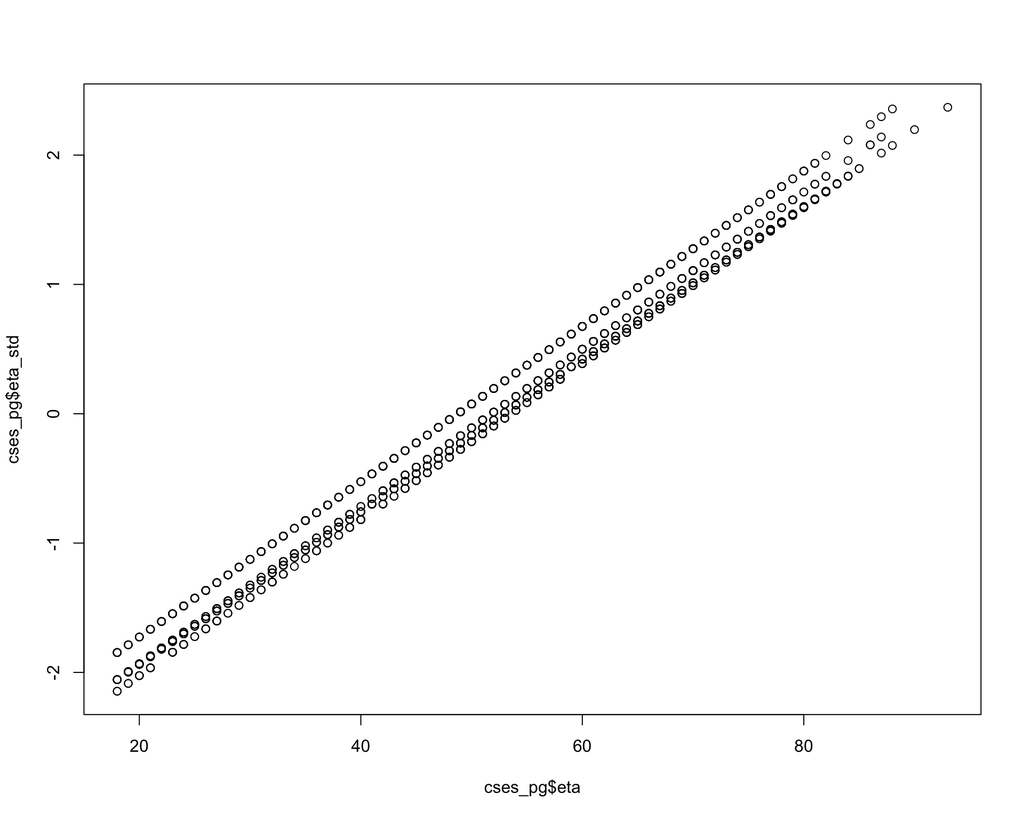

```r
cses_pg <- cses %>%
  group_by(area) %>%
  mutate(
      eta_std = scale(eta)
  )
plot(cses_pg$eta, cses_pg$eta_std)
```

Notare che in questo caso non abbiamo una sola linea (e quindi un solo gruppo di osservazioni) ma più di una. Questo perchè ora il valore $0$, la media, è diversa in ogni gruppo, dato che l’età media cambia tra aree geografiche.

**Nota**: ricordate che ogni volta che utilizzate la funzione `group_by()`, il dataset rimarrà diviso in gruppi! Questa è una caratteristica che distingue il tibble dal data frame: il fatto che mantenga in memoria informazione riguardo l’eventuale divisione in gruppi di un dataset. Se volete fare altre operazioni su tutti i dati (per esempio calcolare la media di una variabile in tutto il dataset) dovete “annullare” il raggruppamento utilizzando la funzione `ungroup()`.

```r
cses_pg <- cses %>%
  group_by(area) %>%
  mutate(
      eta_std = scale(eta)    # Per gruppi
  ) %>%
  ungroup() %>%
  mutate(
      eta_std_2 = scale(eta)  # In tutto il campione
  )
```

## Estrarre informazioni dai dati: `summarize()`

`summarize()` è una delle più importanti funzionalità di `dplyr`, che ci permette di “riassumere” il contenuto di una o più variabili utilizzando statistiche di vario tipo e possibilmente salvando queste informazioni in un oggetto (notare che la stessa funzione può anche essere chiamata `summarise()`, in British English).

Per fare un esempio, possiamo creare una tabella che include media e deviazione standard della variabile `eta` in ogni area geografica:

```r
cses_gr <- cses %>%
  group_by(area) %>%
  summarize(
    eta_m = mean(eta, na.rm = T),
    eta_sd = sd(eta, na.rm = T)
  )
cses_gr
```

```
## # A tibble: 4 x 3
##   area       eta_m eta_sd
##   <chr>      <dbl>  <dbl>
## 1 Centro      51.8   16.5
## 2 Nord-Est    53.6   16.6
## 3 Nord-Ovest  52.8   16.9
## 4 Sud         48.8   16.7
```

## Usare `mutate()` e `summarize()` su più di una variabile alla volta: `across()`

Un’ulteriore caratteristica che rende `dplyr` molto conveniente è la possibilità di generalizzare le funzioni `mutate()` e `summarize()` a più di una variabile. In questo modo non occorrerà ripetere lo stesso comando più volte nel caso si debba applicare la stessa funzione a più variabili (naturalmente la funzione deve essere la stessa).

A partire dalla versione più recente di `dplyr`, è possibile ottenere questo con la funzione `across()`, che può essere utilizzata sia con `mutate` che con `summarize`.

Per esempio, proviamo a usare `grepl()` per creare due variabili dummy che identificano le persone che hanno risposto “immigrazione” alle due domande sul “problema più importante in Italia”, `mip1` e `mip2`:

```r
cses_pg <- cses %>%
  mutate(
    across(
      starts_with("mip"),
      ~ifelse(grepl("migr", .), 1, 0),
      .names = "{.col}_r"
    )
  )
# Per quante persone l'immigrazione è il problema più importante?
mean(cses_pg$mip1_r)
```

```
## [1] 0.05847076
```

```r
# E per quante persone l'immigrazione è il secondo problema più importante?
mean(cses_pg$mip2_r)
```

```
## [1] 0.1009495
```

Nelle versioni precedenti di `dplyr` questa operazione veniva svolta dalle funzioni `mutate_at()` e `summarize_at()`, che funzionano ancora.

È ancora possibile utilizzare `mutate_all()` e `summarize_all()` per applicare la stessa funzione su **tutte** le variabili, con una logica molto simile ad applicare la funzione `apply()` per colonne. Per esempio, se vogliamo sapere quante osservazioni mancanti abbiamo in ogni variabile, possiamo usare `summarize_all()`:

```r
cses %>%
  summarize_all(~sum(is.na(.)))
```

```
##   id sex eta eta_gr mip1 mip2 eco_eval area titstu
## 1  0   0   0      0   62  195       23    0      0
```

Notare che il modo più recente per fare questo è utilizzare `summarize()` e `across()`:

```r
cses %>%
  summarize(
    across(
       everything(),
       ~sum(is.na(.))
    )
  )
```

```
##   id sex eta eta_gr mip1 mip2 eco_eval area titstu
## 1  0   0   0      0   62  195       23    0      0
```